# Building a parametric model of daily precipitation, inferenced from empirical pattern

Andreas Angourakis

28 November 2019

This document contains a progression of steps taken for creating a parametric stochastic model of daily precipitation.

## 0.1 Loading data

- Precipitation (PRECTOT)
- Wind speed at 2m (WS2M)
- Relative Humidity at 2m (RH2M)
- Dew/frost point at 2m (T2MDEW)
- Maximum temperature at 2m (T2M_MAX)
- Minimum temperature at 2m (T2M_MIN)
- All sky insolation incident on a horizontal surface (ALLSKY_SFC_SW_DWN)
- Temperature at 2m (T2M)

```r
weather <- read.csv("POWER_SinglePoint_Daily_19820101_20181231_029d15N_075d72E_3a7e0417.csv", skip = 17)
```

## 0.2 Assessing the data

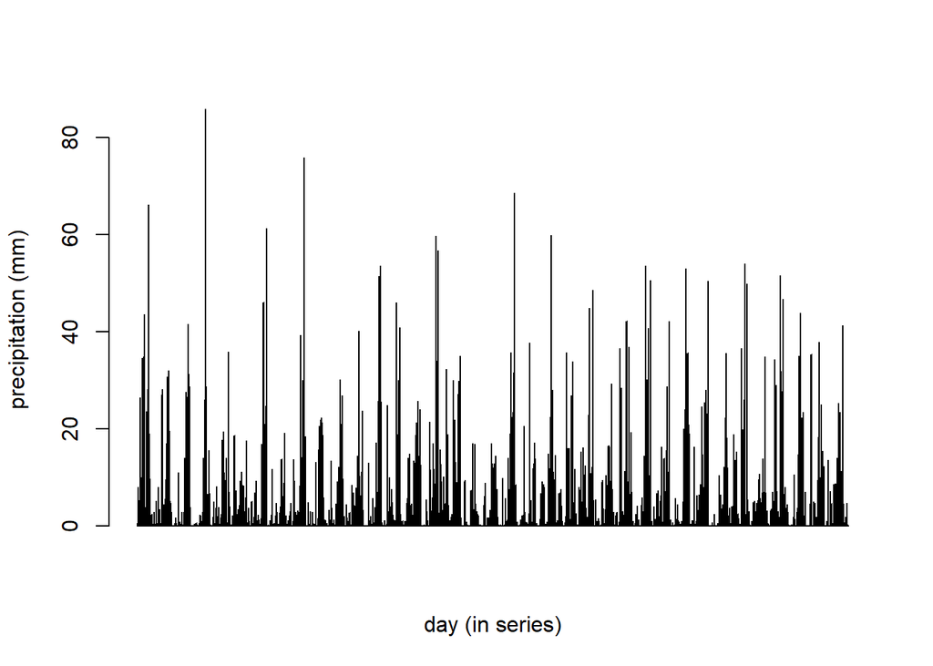

```r
barplot(weather$PRECTOT,
        ylab = "precipitation (mm)", xlab = "day (in series)")
```

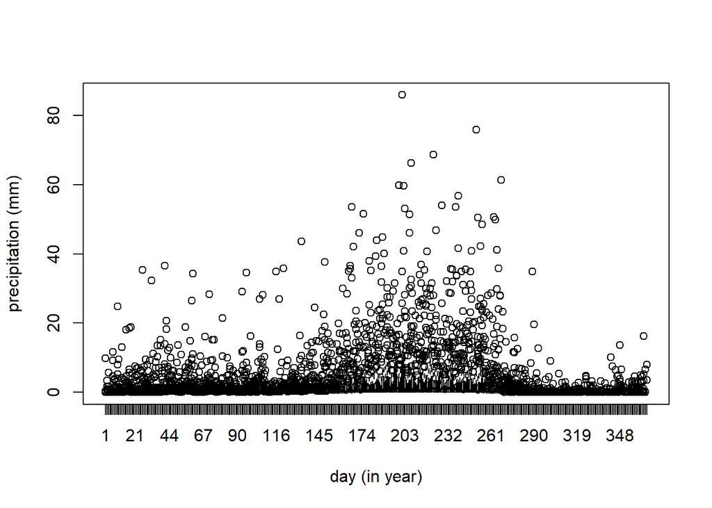

```r
boxplot(data = weather, PRECTOT ~ DOY, ylab = "precipitation (mm)", xlab = "day (in year)")
```

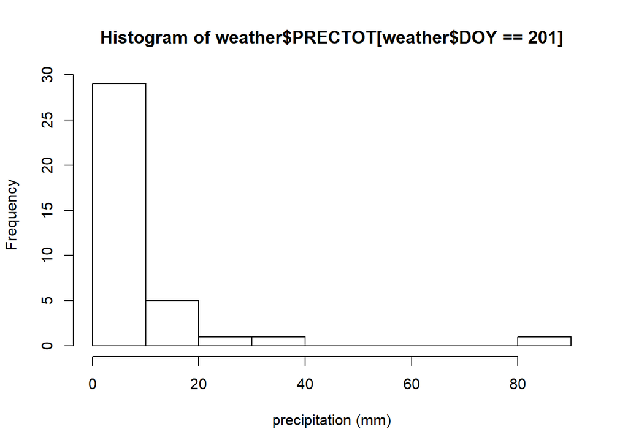

```r
hist(weather$PRECTOT[weather$DOY == 201], xlab = "precipitation (mm)")
```

### 0.2.1 Assess the variability of annual precipitation

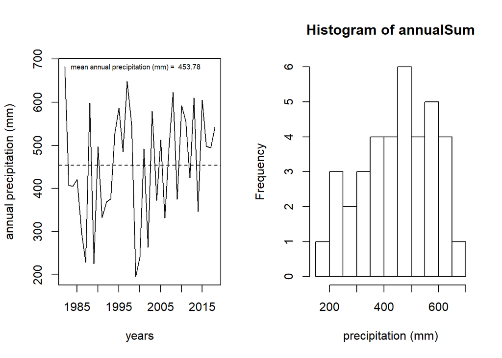

```r
annualSum <- c()

for (year in levels(factor(weather$YEAR)))
{
  annualSum <- c(annualSum, sum(weather$PRECTOT[weather$YEAR == year]))
}

layout(matrix(c(1,2), ncol = 2))

plot(levels(factor(weather$YEAR)), annualSum, type = 'l', xlab = "years", ylab = "annual precipitation (mm)")

abline(h = mean(annualSum), lty = 2)

text(x = levels(factor(weather$YEAR))[0.5 * nlevels(factor(weather$YEAR))],
     y = max(annualSum),
     labels = paste("mean annual precipitation (mm) = ", round(mean(annualSum), digits = 2) ),
     cex = 0.6)

hist(annualSum, xlab = "precipitation (mm)")
```

The annual precipitation is a good candidate to be a parameter of our model (one that can be randomised every iteration using uniform or normal distribution).

### 0.2.2 Getting summary statistics by day of year

```r
summary_DOY <- function(multiYearSeries, doyName = "DOY", varName = "PRECTOT")
{
  meanDailyValues <- c()
  sdDailyValues <- c()
  minDailyValues <- c()
  maxDailyValues <- c()

  for (day in levels(factor(multiYearSeries[, doyName])))
  {
    meanDailyValues <- c(meanDailyValues, mean(multiYearSeries[weather$DOY == day, varName], na.rm = T))
    sdDailyValues <- c(sdDailyValues, sd(multiYearSeries[weather$DOY == day, varName], na.rm = T))
    minDailyValues <- c(minDailyValues, min(multiYearSeries[weather$DOY == day, varName], na.rm = T))
    maxDailyValues <- c(maxDailyValues, max(multiYearSeries[weather$DOY == day, varName], na.rm = T))
  }

  return(
    data.frame(mean = meanDailyValues,
               sd = sdDailyValues,
               min = minDailyValues,
               max = maxDailyValues)
  )
}
```

```r
summaryByDoy_empiric <- summary_DOY(weather)

summary_empiric <- summary(weather$PRECTOT)
summary_empiric$sd <- sd(weather$PRECTOT)
```

## 0.3 Attempting a direct approach to modeling daily precipitation using an exponential probability distribution

```r
n = 33
maxDOY = 366 # max. days in year. more complex simulation can account better for leap years

dayOfYear <- c()
year_sim <- c()
dailyPrecipitation <- c()

for (i in 1:n)
{
  for (day in 1:maxDOY)
  {
    year_sim <- c(year_sim, i)
    dayOfYear <- c(dayOfYear, day)
    dailyPrecipitation <- c(dailyPrecipitation,
                            # exponential model using the mean
                            (- summaryByDoy_empiric$mean[day]) * log(runif(1))
                     )
  }
}

expModelOutput <- data.frame(year_sim, dayOfYear, dailyPrecipitation)

summaryByDoy_expModel <- summary_DOY(expModelOutput, doyName = "dayOfYear", varName = "dailyPrecipitation")

summary_expModel <- summary(expModelOutput$dailyPrecipitation)
summary_expModel$sd <- sd(expModelOutput$dailyPrecipitation)
```

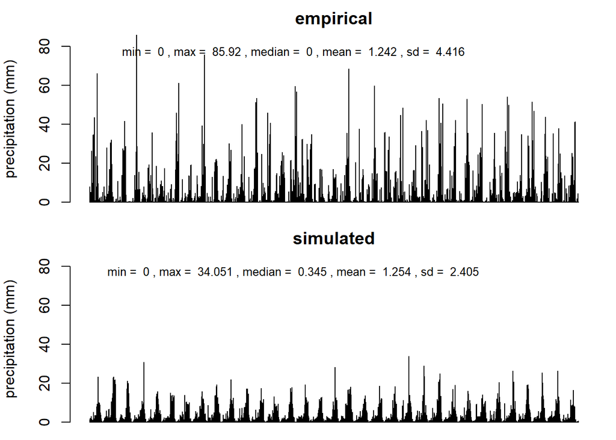

```r
layout(matrix(c(1,2), nrow = 2))

par(mar = c(1,4,2,1))

barplot(weather$PRECTOT,
        ylab = "precipitation (mm)", main = "empirical",
        ylim = c(0, max(c(max(summaryByDoy_empiric$max), max(summaryByDoy_expModel$max)))))

text(x = nrow(weather) / 2, y = 0.9 * max(c(max(summaryByDoy_empiric$max), max(summaryByDoy_expModel$max))),
     labels = paste(
       "min = ", summary_empiric$Min.,
       ", max = ", round(summary_empiric$Max., digits = 3),
       ", median = ", summary_empiric$Median,
       ", mean = ", round(summary_empiric$Mean, digits = 3),
       ", sd = ", round(summary_empiric$sd, digits = 3)
       ),
     cex = 0.8)

barplot(expModelOutput$dailyPrecipitation,
        ylab = "precipitation (mm)", main = "simulated",
        ylim = c(0, max(c(max(summaryByDoy_empiric$max), max(summaryByDoy_expModel$max)))))

text(x = nrow(expModelOutput) / 2, y = 0.9 * max(c(max(summaryByDoy_empiric$max), max(summaryByDoy_expModel$max))),
     labels = paste(
       "min = ", round(summary_expModel[[1]], digits = 3),
       ", max = ", round(summary_expModel[[6]], digits = 3),
       ", median = ", round(summary_expModel[[3]], digits = 3),
       ", mean = ", round(summary_expModel[[4]], digits = 3),
       ", sd = ", round(summary_expModel[[7]], digits = 3)
     ),
     cex = 0.8)
```

### 0.3.1 Compare to input statistics:

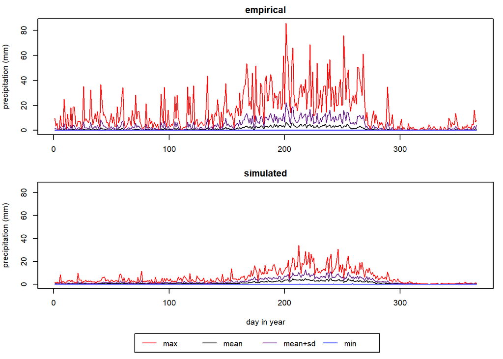

```r
layout(matrix(c(1, 2, 3), nrow = 3), heights = c(10, 10, 2))

par(mar = c(3,4,2,1))

plot(1:nrow(summaryByDoy_empiric), summaryByDoy_empiric$max, col = "red", type = 'l',
     ylab = "precipitation (mm)", main = "empirical",
     ylim = c(0, max(c(summaryByDoy_empiric$max, summaryByDoy_expModel$max))))

lines(1:nrow(summaryByDoy_empiric), summaryByDoy_empiric$mean)
lines(1:nrow(summaryByDoy_empiric), summaryByDoy_empiric$mean + summaryByDoy_empiric$sd, col = "darkorchid4")
lines(1:nrow(summaryByDoy_empiric), summaryByDoy_empiric$min, col = "blue")

par(mar = c(4,4,2,1))

plot(1:nrow(summaryByDoy_expModel), summaryByDoy_expModel$max, col = "red", type = 'l',
     xlab = "day in year",
     ylab = "precipitation (mm)", main = "simulated",
     ylim = c(0, max(c(summaryByDoy_empiric$max, summaryByDoy_expModel$max))))

lines(1:nrow(summaryByDoy_expModel), summaryByDoy_expModel$mean)
lines(1:nrow(summaryByDoy_expModel), summaryByDoy_expModel$mean + summaryByDoy_expModel$sd, col = "darkorchid4")
lines(1:nrow(summaryByDoy_expModel), summaryByDoy_expModel$min, col = "blue")

par(mar = c(0,0,0,0))

plot(c(0, 1), c(0, 1), ann = F, bty = 'n', type = 'n', xaxt = 'n', yaxt = 'n')

legend(x = 0.25, y = 0.8,
       legend = c('max', 'mean', 'mean+sd', 'min'),
       col = c('red', 'black', 'darkorchid4', 'blue'), lty = rep(1, 4),
       horiz = T)
```

# 1 Modelling assuming normal distribution of daily cumulative proportion of the annual precipitation

*Method summary*:  
First we find the curve of daily cumulative proportion of the annual precipitation for multplie years in the dataset. Then, we use the mean and standard deviation of the values on each day (for multiple years) to create multiple simulated curves using a random normal distribution for each day in a year. Last, we derivate the simulated daily precipitation from the simulated curve of cumulative proportions.

## 1.1 Build the curves of the daily cumulative proportion of annual precipitation for every year in the empirical dataset

```r
proportionSeries <- c()
cumulativeProportionSeries <- c()

for (year in levels(factor(weather$YEAR)))
{
  yearSum = sum(weather$PRECTOT[weather$YEAR == year])
  cumPropYear = 0
  for (day in levels(factor(weather$DOY)))
  {
    dayProportion = weather$PRECTOT[weather$YEAR == year & weather$DOY == day] / yearSum
    cumPropYear = cumPropYear + dayProportion

    proportionSeries <- c(proportionSeries,
                                   dayProportion)
    cumulativeProportionSeries <- c(cumulativeProportionSeries,
                                      cumPropYear)
  }
}
propToAnnual <- data.frame(proportionSeries, cumulativeProportionSeries)
```

### 1.1.1 The daily proportion of annual precipitation

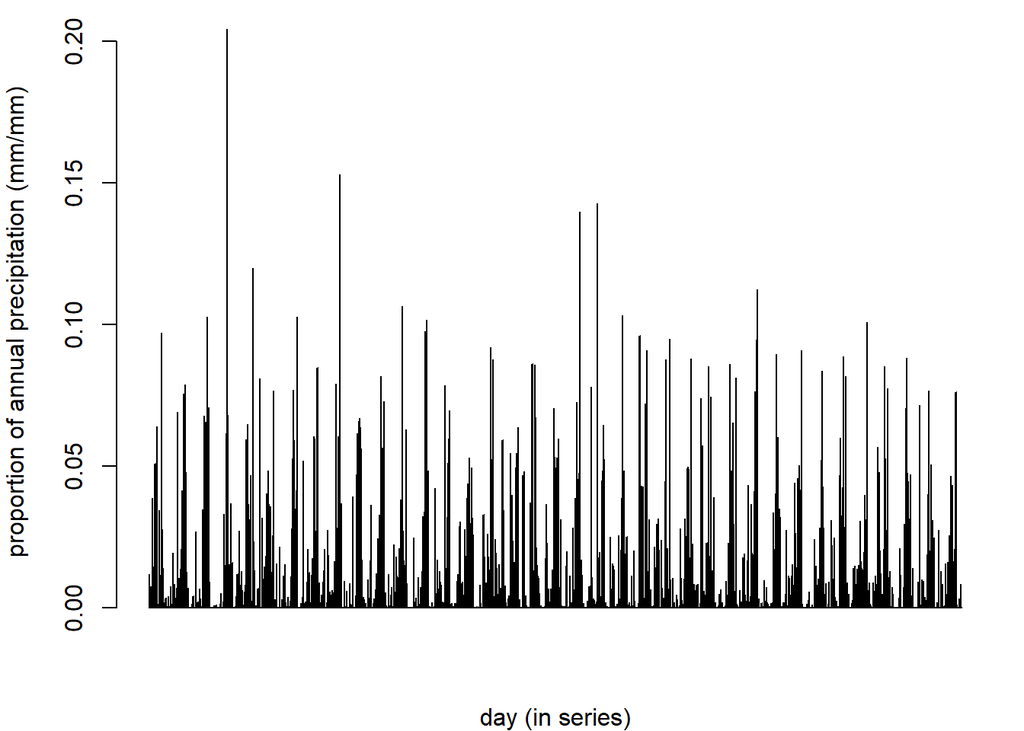

```r
par(mar = c(4, 4, 1, 1))
barplot(propToAnnual$proportionSeries,
        xlab = "day (in series)",
        ylab = "proportion of annual precipitation (mm/mm)")
```

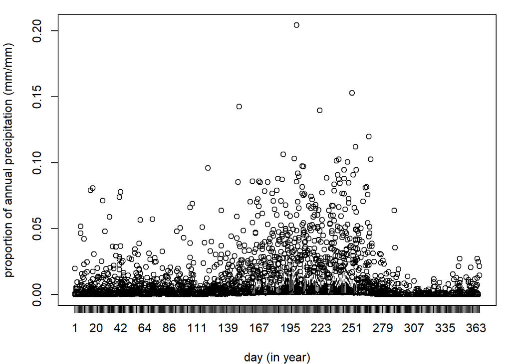

```r
par(mar = c(4, 4, 1, 1))
boxplot(propToAnnual$proportionSeries ~ weather$DOY,
        xlab = "day (in year)",
        ylab = "proportion of annual precipitation (mm/mm)")
```

The pattern should be similar to the one observed in precipitation – the difference is that the proportions depend on the value of annual precipitation of the corresponding year.

### 1.1.2 The curves of the daily cumulative proportion of annual precipitation

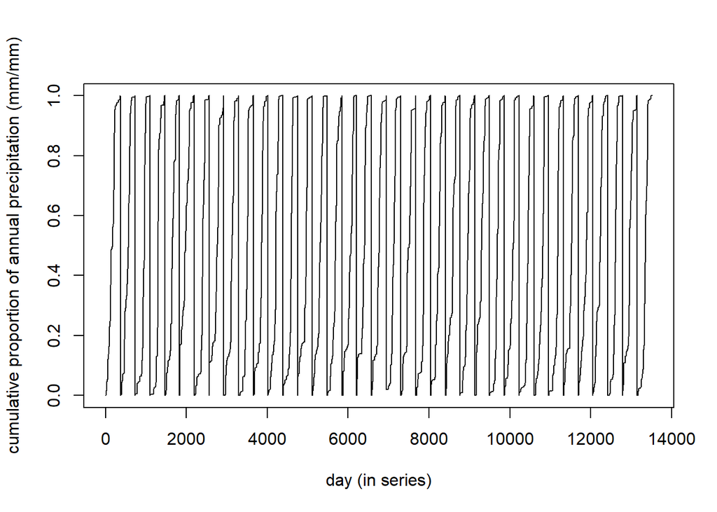

```r
plot(1:length(propToAnnual$proportionSeries), propToAnnual$cumulativeProportionSeries, type = 'l',
     xlab = "day (in series)",
     ylab = "cumulative proportion of annual precipitation (mm/mm)")
```

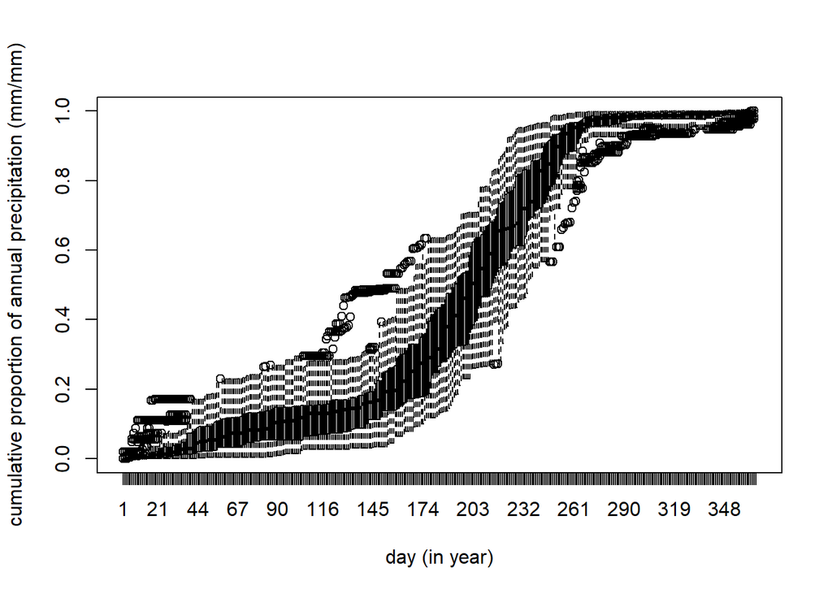

```r
boxplot(propToAnnual$cumulativeProportionSeries ~ weather$DOY,
        xlab = "day (in year)",
        ylab = "cumulative proportion of annual precipitation (mm/mm)")
```

Although limited to the 0-1 interval, the variability of the curve daily values is much more similar to a normal distribution.

## 1.2 Get summary statistics for each of the curves’ daily values

```r
cumPropDailyMean <- c()
cumPropDailySD <- c()
cumPropDailyMin <- c()
cumPropDailyMax <- c()

for (day in levels(factor(weather$DOY)))
{
  cumPropDailyMean <- c(cumPropDailyMean, mean(propToAnnual$cumulativeProportionSeries[weather$DOY == day]))
  cumPropDailySD <- c(cumPropDailySD, sd(propToAnnual$cumulativeProportionSeries[weather$DOY == day]))
  cumPropDailyMin <- c(cumPropDailyMin, min(propToAnnual$cumulativeProportionSeries[weather$DOY == day]))
  cumPropDailyMax <- c(cumPropDailyMax, max(propToAnnual$cumulativeProportionSeries[weather$DOY == day]))
}
```

## 1.3 Simulate n iterations of the curve

```r
set.seed(0)

n = 33
maxDOY = 366 # max. days in year. more complex simulation can account better for leap years

dayOfYear <- c()
year_sim <- c()
dailyCumPropPrecipitation <- c()

for (i in 1:n)
{
  for (day in 1:maxDOY)
  {
    year_sim <- c(year_sim, i)
    dayOfYear <- c(dayOfYear, day)
    dailyCumPropPrecipitation <- c(dailyCumPropPrecipitation,
                                   rnorm(1, cumPropDailyMean[day], cumPropDailySD[day])
                     )
  }
}

# limit the values between 0-1
# (this tends to create concentrations in 0 and 1 at the beggining and end of the curve; not undesireble)
dailyCumPropPrecipitation <- sapply(dailyCumPropPrecipitation, function(x) min(1, max(0, x)))

# "correct" negative slopes
# Because the curves represent cumulative values,
# the next value must always be equal or greater than the previous value.
for (i in 1:length(dailyCumPropPrecipitation))
{
  if(dayOfYear[i] > 1)
  {
    if (dailyCumPropPrecipitation[i] < dailyCumPropPrecipitation[i - 1])
    {
      # adjunst value to the last, if greater
      dailyCumPropPrecipitation[i] <- max(dailyCumPropPrecipitation[i], dailyCumPropPrecipitation[i - 1])
      # This tends to bend the curve towards the greater values, meaning earlier precipitation events
      # (not desirible)
      # alternative option: adjust to average between current and last values (UNSOLVED)
      #dailyCumPropPrecipitation[i] <- mean(dailyCumPropPrecipitation[i], dailyCumPropPrecipitation[i - 1])
      #dailyCumPropPrecipitation[i - 1] <- dailyCumPropPrecipitation[i]
    }
  }
}

normCumModelOutput <- data.frame(year_sim, dayOfYear, dailyCumPropPrecipitation)
```

### 1.3.1 Compare empirical and simulated curves:

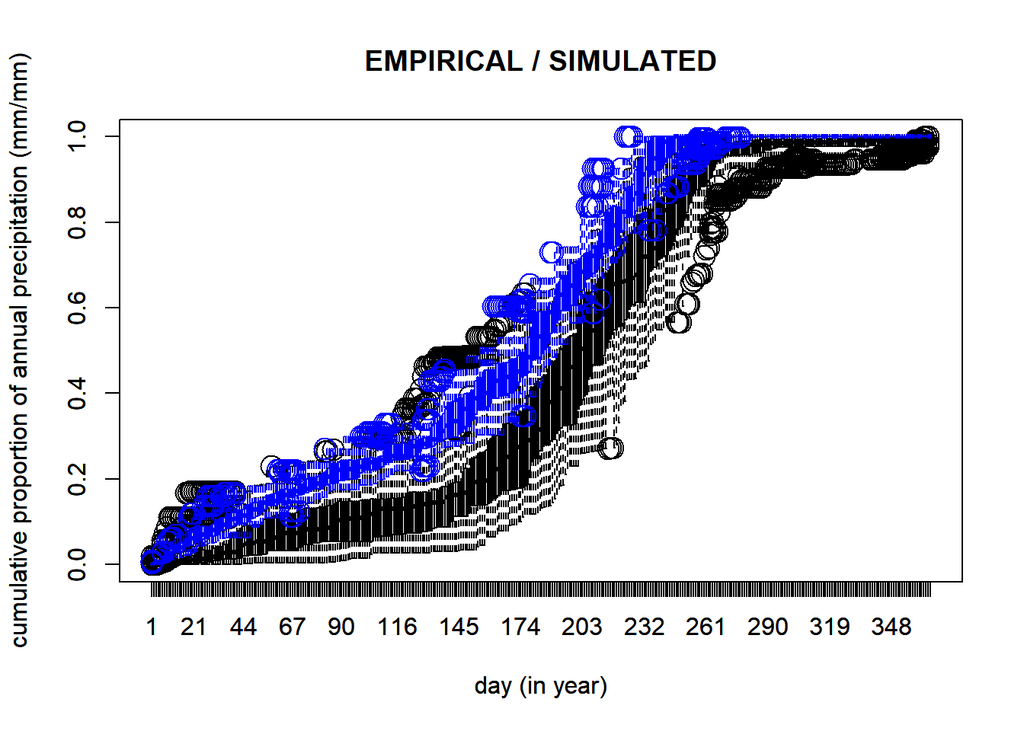

```r
boxplot(propToAnnual$cumulativeProportionSeries ~ weather$DOY, cex = 2,
        xlab = "day (in year)",
        ylab = "cumulative proportion of annual precipitation (mm/mm)",
        main = "EMPIRICAL / SIMULATED")
par(new=TRUE)
boxplot(normCumModelOutput$dailyCumPropPrecipitation ~ normCumModelOutput$dayOfYear, cex = 2,
        xlab = "day (in year)",
        ylab = "cumulative proportion of annual precipitation (mm/mm)",
        border = "blue")
```

## 1.4 Derivate daily precipitation values from simulated curves These are the difference between day i and day i - 1

```r
dailyPropPrecipitation <- normCumModelOutput$dailyCumPropPrecipitation

for (i in 1:length(dailyPropPrecipitation))
{
  if(normCumModelOutput$dayOfYear[i] > 1) # dailyPropPrecipitation = dailyCumPropPrecipitation, if day = 1
  {
    dailyPropPrecipitation[i] <- normCumModelOutput$dailyCumPropPrecipitation[i] - normCumModelOutput$dailyCumPropPrecipitation[i - 1]
  }
}

normCumModelOutput$dailyPropPrecipitation <- dailyPropPrecipitation

summaryByDoy_normCumModel <- summary_DOY(normCumModelOutput, doyName = "dayOfYear", varName = "dailyPropPrecipitation")

summary_normCumModel <- summary(normCumModelOutput$dailyPropPrecipitation)
summary_normCumModel$sd <- sd(normCumModelOutput$dailyPropPrecipitation)
```

```r
annualSum_modelPar = mean(annualSum) # (mm)

summaryPrecip_model <- summary(normCumModelOutput$dailyPropPrecipitation * annualSum_modelPar)
```

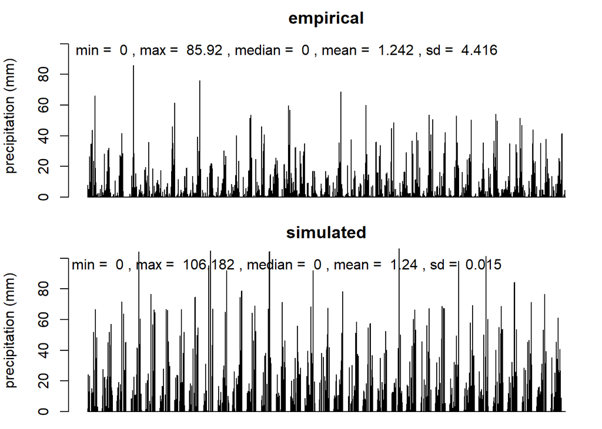

```r
layout(matrix(c(1,2), nrow = 2))

par(mar = c(1,4,2,1))

barplot(weather$PRECTOT,
        ylab = "precipitation (mm)", main = "empirical",
        ylim = c(0, max(c(summaryByDoy_empiric$max, summaryByDoy_normCumModel$max * annualSum_modelPar))))

text(x = nrow(weather) / 2, y = 0.9 * max(c(summaryByDoy_empiric$max, summaryByDoy_normCumModel$max * annualSum_modelPar)),
     labels = paste(
       "min = ", round(summary_empiric$Min., digits = 3),
       ", max = ", round(summary_empiric$Max., digits = 3),
       ", median = ", round(summary_empiric$Median, digits = 3),
       ", mean = ", round(summary_empiric$Mean, digits = 3),
       ", sd = ", round(summary_empiric$sd, digits = 3)
       ))

barplot(normCumModelOutput$dailyPropPrecipitation * annualSum_modelPar,
        ylab = "precipitation (mm)", main = "simulated",
        ylim = c(0, max(c(summaryByDoy_empiric$max, summaryByDoy_normCumModel$max * annualSum_modelPar))))

text(x = nrow(normCumModelOutput) / 2, y = 0.9 * max(c(summaryByDoy_empiric$max, summaryByDoy_normCumModel$max * annualSum_modelPar)),
     labels = paste(
       "min = ", summary_normCumModel$Min. * annualSum_modelPar,
       ", max = ", round(summary_normCumModel$Max. * annualSum_modelPar, digits = 3),
       ", median = ", summary_normCumModel$Media * annualSum_modelPar,
       ", mean = ", round(summary_normCumModel$Mean * annualSum_modelPar, digits = 3),
       ", sd = ", round(summary_normCumModel$sd, digits = 3)
     ))
```

### 1.5.1 Compare to input statistics:

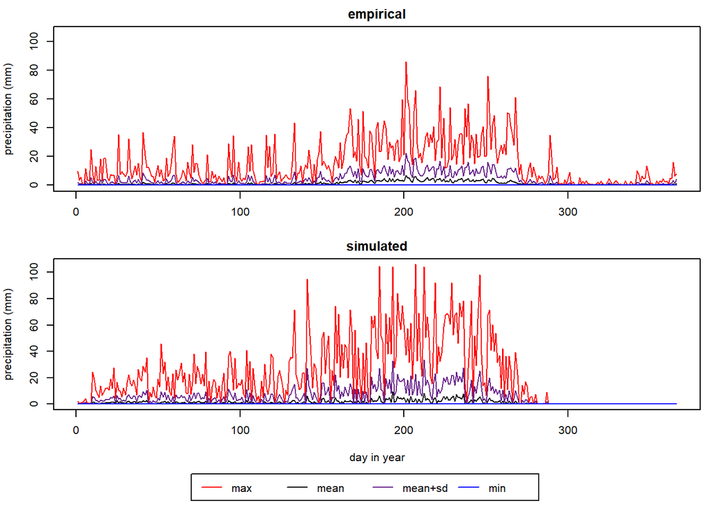

```r
layout(matrix(c(1, 2, 3), nrow = 3), heights = c(10, 10, 2))

par(mar = c(3,4,2,1))

plot(1:nrow(summaryByDoy_empiric), summaryByDoy_empiric$max, col = "red", type = 'l',
     ylab = "precipitation (mm)", main = "empirical",
     ylim = c(0, max(c(summaryByDoy_empiric$max, summaryByDoy_normCumModel$max * annualSum_modelPar))))

lines(1:nrow(summaryByDoy_empiric), summaryByDoy_empiric$mean)
lines(1:nrow(summaryByDoy_empiric),
      summaryByDoy_empiric$mean + summaryByDoy_empiric$sd,
      col = "darkorchid4")
lines(1:nrow(summaryByDoy_empiric), summaryByDoy_empiric$min, col = "blue")

par(mar = c(4,4,2,1))

plot(1:nrow(summaryByDoy_normCumModel), summaryByDoy_normCumModel$max * annualSum_modelPar,
     col = "red", type = 'l',
     xlab = "day in year",
     ylab = "precipitation (mm)", main = "simulated",
     ylim = c(0, max(c(summaryByDoy_empiric$max, summaryByDoy_normCumModel$max * annualSum_modelPar))))

lines(1:nrow(summaryByDoy_normCumModel), summaryByDoy_normCumModel$mean * annualSum_modelPar)
lines(1:nrow(summaryByDoy_normCumModel),
      (summaryByDoy_normCumModel$mean + summaryByDoy_normCumModel$sd) * annualSum_modelPar,
      col = "darkorchid4")
lines(1:nrow(summaryByDoy_normCumModel), summaryByDoy_normCumModel$min * annualSum_modelPar, col = "blue")

par(mar = c(0,0,0,0))

plot(c(0, 1), c(0, 1), ann = F, bty = 'n', type = 'n', xaxt = 'n', yaxt = 'n')

legend(x = 0.25, y = 0.8,
       legend = c('max', 'mean', 'mean+sd', 'min'),
       col = c('red', 'black', 'darkorchid4', 'blue'), lty = rep(1, 4),
       horiz = T)
```

### 1.5.2 Check the variability of annual precipitation

```r
annualSum_model <- c()

for (year in levels(factor(normCumModelOutput$year_sim)))
{
  annualSum_model <- c(annualSum_model, sum(normCumModelOutput$dailyPropPrecipitation[normCumModelOutput$year_sim == year] * annualSum_modelPar))
}
```

Only to confirm that the daily proportion of annual precipitation always sum up to 1 meaning that the annual precipitation is really controlled as a parameter (i.e. annualSum_modelPar)

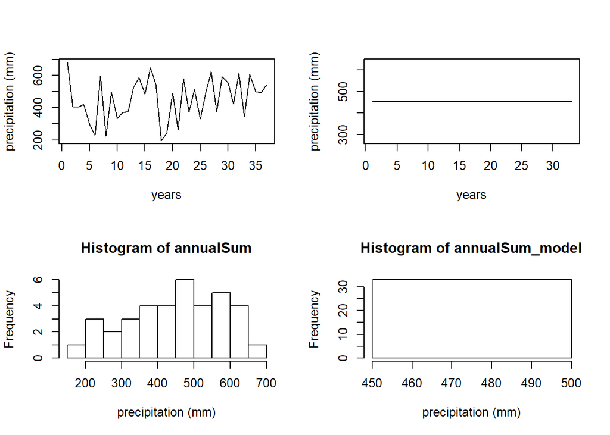

```r
layout(matrix(c(1,2,3,4), nrow = 2))

plot(1:length(annualSum), annualSum, type = 'l', xlab = "years", ylab = "precipitation (mm)")

hist(annualSum, xlab = "precipitation (mm)")

plot(1:length(annualSum_model), annualSum_model, type = 'l', xlab = "years", ylab = "precipitation (mm)")

hist(annualSum_model, xlab = "precipitation (mm)")
```

**FAIL**: the simulated data reflect well the variability of the data and controls the total amount of precipitation in a year. However, simulated precipitation falls to early and, thus, too concentrated, raising the daily maximum much beyond the empirical maximum while creating longer periods of drought.

# 2 Modelling assuming double logistic curve for daily cumulative proportion of the annual precipitation

*Method summary*:  
The simulated daily precipitation is obtained by using a double logistic curve as the propability function of (Shabani et al. 2018, http://doi.org/10.1017/S0021859617000934).

## 2.1 Define double logistic function

```r
doubleLogistic <- function(dayOfYear,
                           plateauValue, inflection1, rate1, inflection2, rate2
                           #m1, m2, m3, m4, m5, m6, m7
                           #plateauValue, a, b, c, d
                           )
{
  return(
    (plateauValue / (1 + exp((inflection1 - dayOfYear) * rate1))) + ((1 - plateauValue) / (1 + exp((inflection2 - dayOfYear) * rate2)))
    # Elmore et al. 2012
    # m1 + (m2 - m7 * dayOfYear) * (
    #   (1 / (1 + exp((m3 - dayOfYear) / m4))) + (1 / (1 + exp((m5 - dayOfYear) / m6)))
    # )
    # Shabani et al. 2018:
    #(plateauValue / (1 + exp(-a * dayOfYear + b))) + ((1 - plateauValue) / (1 + exp(-c * dayOfYear + d)))
  )
}

doubleLogisticCurve <- function(start.x, end.x, plateauValue, inflection1, rate1, inflection2, rate2)
{
  curve <- c()
  for (i in start.x:end.x)
  {
    curve <- c(curve, doubleLogistic(i, plateauValue, inflection1, rate1, inflection2, rate2))
  }
  return(curve)
}
```

Brief parameter exploration:

```r
colours <- rainbow(10)
plateauValues <- round(seq(from = 0.01, to = 0.8, length.out = 10), digits = 2)
inflection1Values <- round(seq(from = 20, to = 100, length.out = 10), digits = 2)
rate1Values <- round(seq(from = 0.1, to = 0.5, length.out = 10), digits = 2)
inflection2Values <- round(seq(from = 150, to = 300, length.out = 10), digits = 2)
rate2Values <- round(seq(from = 0.04, to = 0.08, length.out = 10), digits = 2)
```

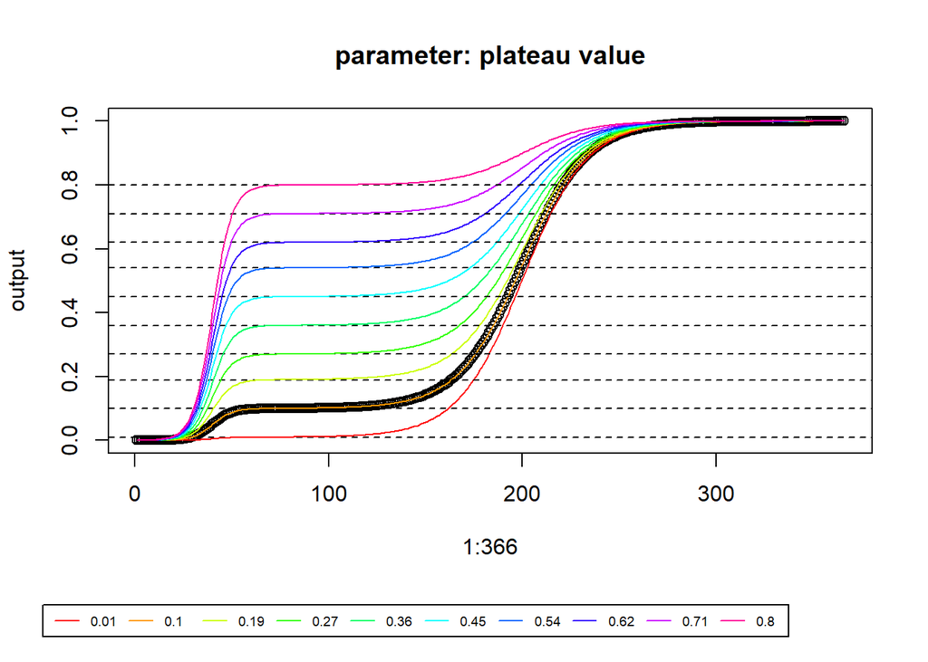

```r
layout(matrix(1:2, nrow = 2), heights = c(8, 1))

# plateau value
plot(1:366,
     doubleLogisticCurve(
       start.x = 1, end.x = 366,
       plateauValue = 0.1, inflection1 = 40, rate1 = 0.2, inflection2 = 200, rate2 = 0.06),
     ylab = "output", main = "parameter: plateau value")

for (i in 1:10)
{
  abline(h = plateauValues[i], lty = 2)
  lines(1:366,
        doubleLogisticCurve(
          start.x = 1, end.x = 366,
          plateauValue = plateauValues[i], inflection1 = 40, rate1 = 0.2, inflection2 = 200, rate2 = 0.06),
        col = colours[i])
}

par(mar = c(0,0,0,0), cex = 0.6)

plot(c(0, 1), c(0, 1), ann = F, bty = 'n', type = 'n', xaxt = 'n', yaxt = 'n')

legend(x = 0.01, y = 0.8,
       legend = as.character(plateauValues),
       col = colours, lty = rep(1, 4),
       horiz = T)
```

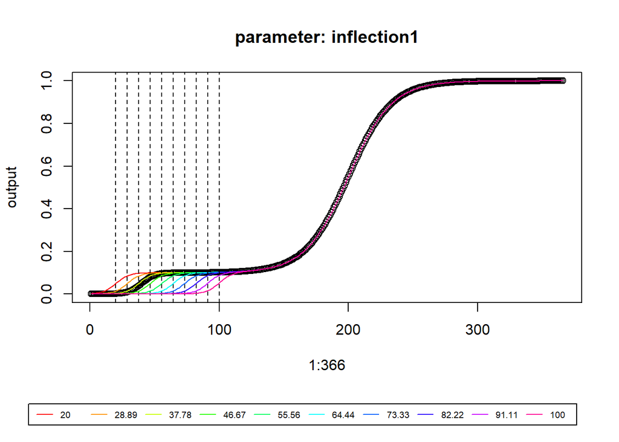

```r
layout(matrix(1:2, nrow = 2), heights = c(8, 1))

# inflection 1
plot(1:366,
     doubleLogisticCurve(
       start.x = 1, end.x = 366,
       plateauValue = 0.1, inflection1 = 40, rate1 = 0.2, inflection2 = 200, rate2 = 0.06),
     ylab = "output", main = "parameter: inflection1")

for (i in 1:10)
{
  abline(v = inflection1Values[i], lty = 2)
  lines(1:366,
        doubleLogisticCurve(
          start.x = 1, end.x = 366,
          plateauValue = 0.1, inflection1 = inflection1Values[i], rate1 = 0.2, inflection2 = 200, rate2 = 0.06),
        col = colours[i])
}

par(mar = c(0,0,0,0), cex = 0.6)

plot(c(0, 1), c(0, 1), ann = F, bty = 'n', type = 'n', xaxt = 'n', yaxt = 'n')

legend(x = 0.01, y = 0.8,
       legend = as.character(inflection1Values),
       col = colours, lty = rep(1, 4),
       horiz = T)
```

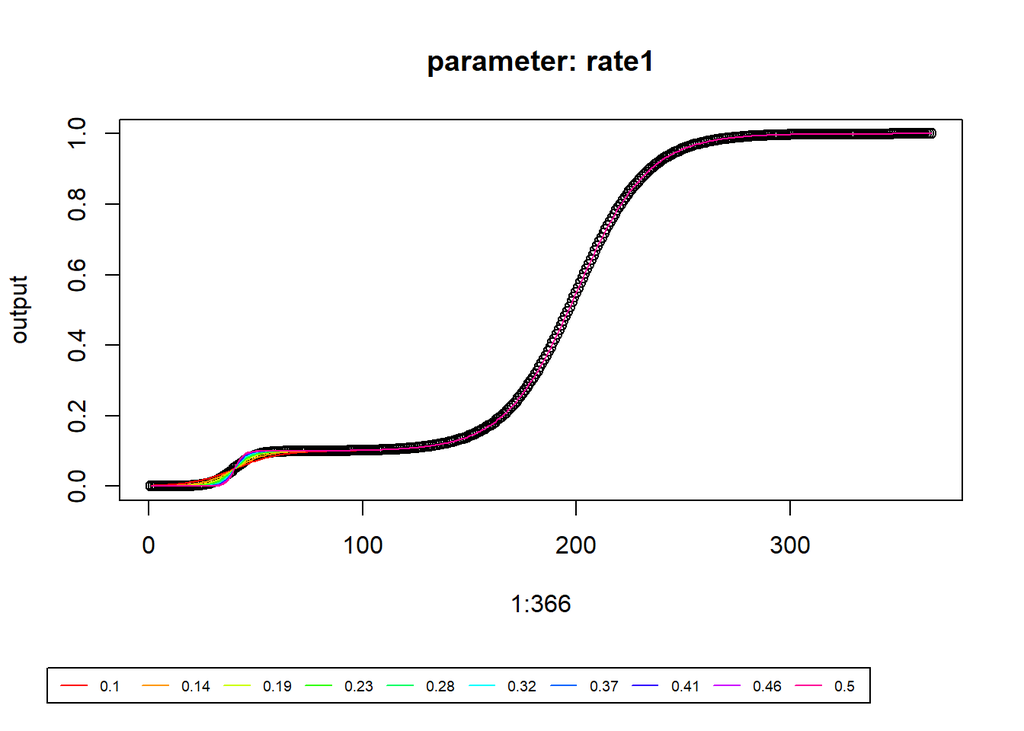

```r
layout(matrix(1:2, nrow = 2), heights = c(8, 1))

# rate 1
plot(1:366,
     doubleLogisticCurve(
       start.x = 1, end.x = 366,
       plateauValue = 0.1, inflection1 = 40, rate1 = 0.2, inflection2 = 200, rate2 = 0.06),
     ylab = "output", main = "parameter: rate1")

for (i in 1:10)
{
  lines(1:366,
        doubleLogisticCurve(
          start.x = 1, end.x = 366,
          plateauValue = 0.1, inflection1 = 40, rate1 = rate1Values[i], inflection2 = 200, rate2 = 0.06),
        col = colours[i])
}

par(mar = c(0,0,0,0), cex = 0.6)

plot(c(0, 1), c(0, 1), ann = F, bty = 'n', type = 'n', xaxt = 'n', yaxt = 'n')

legend(x = 0.01, y = 0.8,
       legend = as.character(rate1Values),
       col = colours, lty = rep(1, 4),
       horiz = T)
```

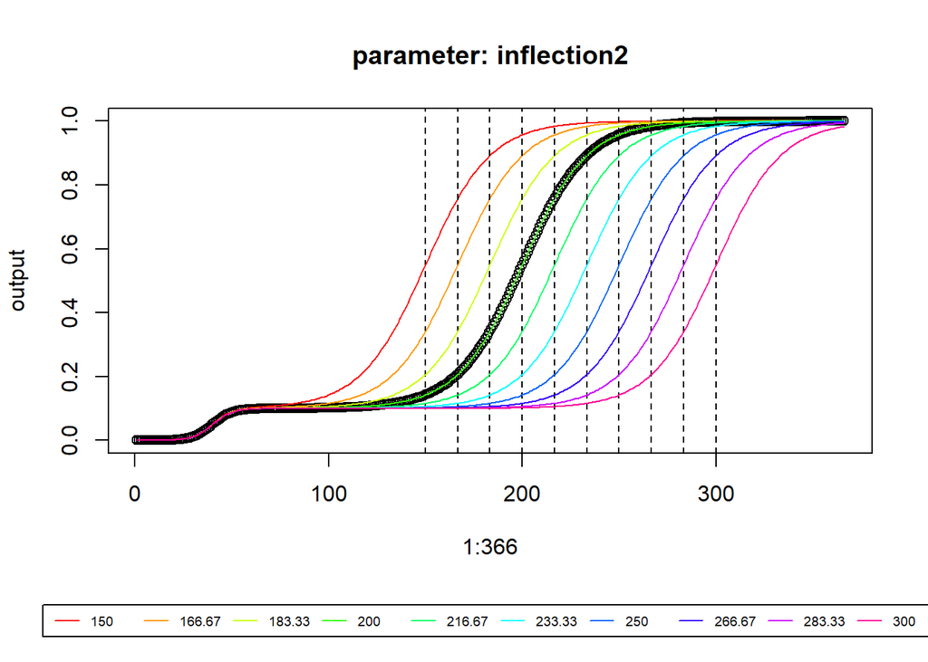

```r
layout(matrix(1:2, nrow = 2), heights = c(8, 1))

# inflection 2
plot(1:366,
     doubleLogisticCurve(
       start.x = 1, end.x = 366,
       plateauValue = 0.1, inflection1 = 40, rate1 = 0.2, inflection2 = 200, rate2 = 0.06),
     ylab = "output", main = "parameter: inflection2")

for (i in 1:10)
{
  abline(v = inflection2Values[i], lty = 2)
  lines(1:366,
        doubleLogisticCurve(
          start.x = 1, end.x = 366,
          plateauValue = 0.1, inflection1 = 40, rate1 = 0.2, inflection2 = inflection2Values[i], rate2 = 0.06),
        col = colours[i])
}

par(mar = c(0,0,0,0), cex = 0.6)

plot(c(0, 1), c(0, 1), ann = F, bty = 'n', type = 'n', xaxt = 'n', yaxt = 'n')

legend(x = 0.01, y = 0.8,
       legend = as.character(inflection2Values),
       col = colours, lty = rep(1, 4),
       horiz = T)
```

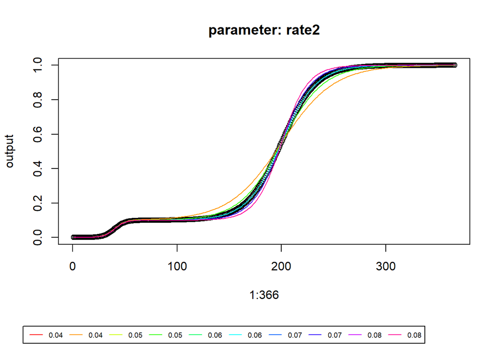

```r
layout(matrix(1:2, nrow = 2), heights = c(8, 1))

# rate 2
plot(1:366,
     doubleLogisticCurve(
       start.x = 1, end.x = 366,
       plateauValue = 0.1, inflection1 = 40, rate1 = 0.2, inflection2 = 200, rate2 = 0.06),
     ylab = "output", main = "parameter: rate2")

for (i in 1:10)
{
  lines(1:366,
        doubleLogisticCurve(
          start.x = 1, end.x = 366,
          plateauValue = 0.1, inflection1 = 40, rate1 = 0.2, inflection2 = 200, rate2 = rate2Values[i]),
        col = colours[i])
}

par(mar = c(0,0,0,0), cex = 0.6)

plot(c(0, 1), c(0, 1), ann = F, bty = 'n', type = 'n', xaxt = 'n', yaxt = 'n')

legend(x = 0.01, y = 0.8,
       legend = as.character(rate2Values),
       col = colours, lty = rep(1, 4),
       horiz = T)
```

## 2.2 Simulate n iterations of the curve

```r
set.seed(0)

n = 33
maxDOY = 366 # max. days in year. more complex simulation can account better for leap years

dayOfYear <- c()
year_sim <- c()
dailyCumPropPrecipitation <- c()

for (i in 1:n)
{
  plateauValue = min(1, max(0, rnorm(1, 0.09, 0.05)))
  inflection1 = min(maxDOY, max(1, rnorm(1, 40, 20)))
  rate1 = max(0, rnorm(1, 0.08, 0.02))
  inflection2 = min(maxDOY, max(1, rnorm(1, 210, 20)))
  rate2 = max(0, rnorm(1, 0.05, 0.01))

  for (day in 1:maxDOY)
  {
    year_sim <- c(year_sim, i)
    dayOfYear <- c(dayOfYear, day)
    dailyCumPropPrecipitation <- c(dailyCumPropPrecipitation,
                                   doubleLogistic(
                                     dayOfYear = day,
                                     plateauValue = plateauValue,
                                     inflection1 = inflection1,
                                     rate1 = rate1,
                                     inflection2 = inflection2,
                                     rate2 = rate2
                                     )
                     )
  }
}

# algorithm to break continuous pattern
nSamplesPerYear = 200
maxSampleSize = 10
for (year in levels(factor(year_sim)))
{
  for (i in 1:nSamplesPerYear)
  {
    # get a decreasing sample size proportionally to sample i
    thisSampleSize = ceiling(maxSampleSize * i / nSamplesPerYear)
    # get random day of year
    rainDOY = round(runif(1, min = 1, max = maxDOY))
    # set sample limits
    earliestNeighbour = max(1, rainDOY - thisSampleSize)
    latestNeighbour = min(366, rainDOY + thisSampleSize)
    # get mean of neighbourhood
    meanNeighbourhood = mean(dailyCumPropPrecipitation[year_sim == year &
                                                         dayOfYear >= earliestNeighbour &
                                                         dayOfYear <= latestNeighbour])
    # assign mean to all days in neighbourhood
    for (j in earliestNeighbour:latestNeighbour)
    {
      dailyCumPropPrecipitation[year_sim == year & dayOfYear == j] <- meanNeighbourhood
    }
  }
}

doubleLogCumModelOutput <- data.frame(year_sim, dayOfYear, dailyCumPropPrecipitation)
```

### 2.2.1 Compare empirical and simulated curves

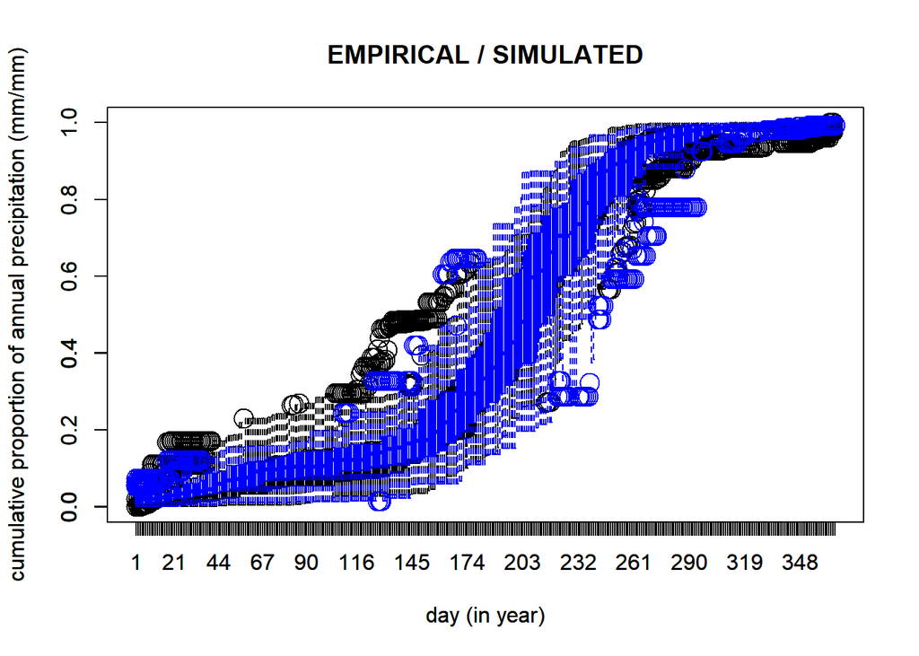

```r
boxplot(propToAnnual$cumulativeProportionSeries ~ weather$DOY, cex = 2,
        xlab = "day (in year)",
        ylab = "cumulative proportion of annual precipitation (mm/mm)",
        main = "EMPIRICAL / SIMULATED")
par(new=TRUE)
boxplot(doubleLogCumModelOutput$dailyCumPropPrecipitation ~ doubleLogCumModelOutput$dayOfYear,
        cex = 2,
        xlab = "day (in year)",
        ylab = "cumulative proportion of annual precipitation (mm/mm)",
        border = "blue")
```

## 2.3 Derivate daily precipitation values from simulated curves These are the difference between day i and day i - 1

```r
dailyPropPrecipitation <- doubleLogCumModelOutput$dailyCumPropPrecipitation

for (i in 1:length(dailyPropPrecipitation))
{
  if(doubleLogCumModelOutput$dayOfYear[i] > 1) # dailyPropPrecipitation = dailyCumPropPrecipitation, if day = 1
  {
    dailyPropPrecipitation[i] <- doubleLogCumModelOutput$dailyCumPropPrecipitation[i] - doubleLogCumModelOutput$dailyCumPropPrecipitation[i - 1]
  }
}

doubleLogCumModelOutput$dailyPropPrecipitation <- dailyPropPrecipitation

summaryByDoy_doubleLogCumModel <- summary_DOY(doubleLogCumModelOutput, doyName = "dayOfYear", varName = "dailyPropPrecipitation")

summary_doubleLogCumModel <- summary(doubleLogCumModelOutput$dailyPropPrecipitation)
summary_doubleLogCumModel$sd <- sd(doubleLogCumModelOutput$dailyPropPrecipitation)
```

```r
annualSum_modelPar = mean(annualSum) # (mm)

summaryPrecip_empiric <- summary(weather$PRECTOT)
summaryPrecip_model <- summary(doubleLogCumModelOutput$dailyPropPrecipitation * annualSum_modelPar)
```

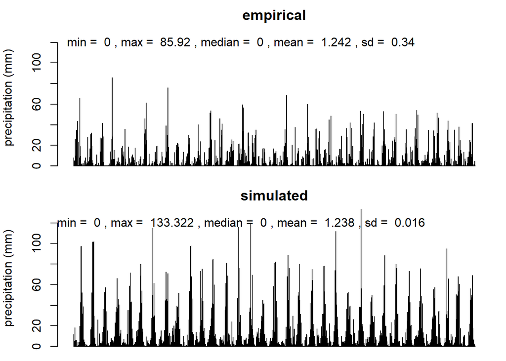

```r
layout(matrix(c(1,2), nrow = 2))

par(mar = c(1,4,2,1))

barplot(weather$PRECTOT,
        ylab = "precipitation (mm)", main = "empirical",
        ylim = c(0, max(c(summaryByDoy_empiric$max, summaryByDoy_doubleLogCumModel$max * annualSum_modelPar))))

text(x = nrow(weather) / 2, y = 0.9 * max(c(summaryByDoy_empiric$max, summaryByDoy_doubleLogCumModel$max * annualSum_modelPar)),
     labels = paste(
       "min = ", summaryPrecip_empiric[1],
       ", max = ", round(summaryPrecip_empiric[6], digits = 3),
       ", median = ", summaryPrecip_empiric[3],
       ", mean = ", round(summaryPrecip_empiric[4], digits = 3),
       ", sd = ", round(summaryPrecip_empiric[5], digits = 3)
       ))

barplot(doubleLogCumModelOutput$dailyPropPrecipitation * annualSum_modelPar,
        ylab = "precipitation (mm)", main = "simulated",
        ylim = c(0, max(c(summaryByDoy_empiric$max, summaryByDoy_doubleLogCumModel$max * annualSum_modelPar))))

text(x = nrow(doubleLogCumModelOutput) / 2, y = 0.9 * max(c(summaryByDoy_empiric$max, summaryByDoy_doubleLogCumModel$max * annualSum_modelPar)),
     labels = paste(
       "min = ", round(summary_doubleLogCumModel$Min. * annualSum_modelPar, digits = 3),
       ", max = ", round(summary_doubleLogCumModel$Max. * annualSum_modelPar, digits = 3),
       ", median = ", round(summary_doubleLogCumModel$Median * annualSum_modelPar, digits = 3),
       ", mean = ", round(summary_doubleLogCumModel$Mean * annualSum_modelPar, digits = 3),
       ", sd = ", round(summary_doubleLogCumModel$sd, digits = 3)
     ))
```

### 2.4.1 Compare to input statistics:

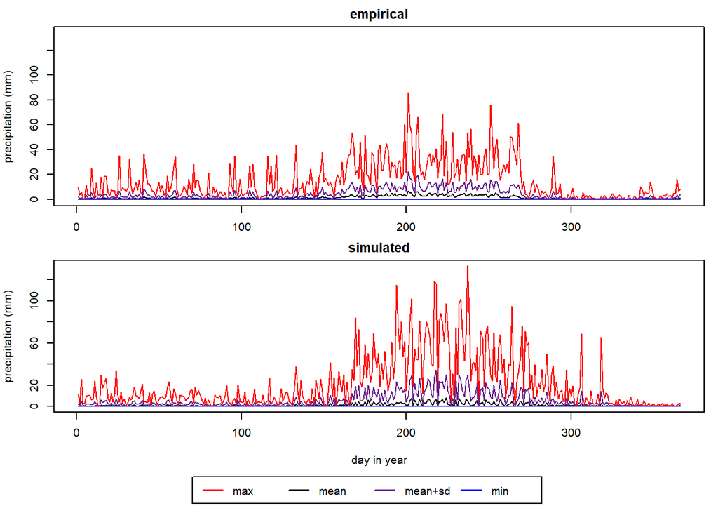

```r
layout(matrix(c(1, 2, 3), nrow = 3), heights = c(10, 10, 2))

par(mar = c(2,4,2,1))

plot(1:nrow(summaryByDoy_empiric), summaryByDoy_empiric$max, col = "red", type = 'l',
     ylab = "precipitation (mm)", main = "empirical",
     ylim = c(0, max(c(summaryByDoy_empiric$max, summaryByDoy_doubleLogCumModel$max * annualSum_modelPar))))

lines(1:nrow(summaryByDoy_empiric), summaryByDoy_empiric$mean)
lines(1:nrow(summaryByDoy_empiric),
      summaryByDoy_empiric$mean + summaryByDoy_empiric$sd,
      col = "darkorchid4")
lines(1:nrow(summaryByDoy_empiric), summaryByDoy_empiric$min, col = "blue")

par(mar = c(4,4,2,1))

plot(1:nrow(summaryByDoy_doubleLogCumModel), summaryByDoy_doubleLogCumModel$max * annualSum_modelPar,
     col = "red", type = 'l',
     xlab = "day in year",
     ylab = "precipitation (mm)", main = "simulated",
     ylim = c(0, max(c(summaryByDoy_empiric$max, summaryByDoy_doubleLogCumModel$max * annualSum_modelPar))))

lines(1:nrow(summaryByDoy_doubleLogCumModel), summaryByDoy_doubleLogCumModel$mean * annualSum_modelPar)
lines(1:nrow(summaryByDoy_doubleLogCumModel),
      (summaryByDoy_doubleLogCumModel$mean + summaryByDoy_doubleLogCumModel$sd) * annualSum_modelPar,
      col = "darkorchid4")
lines(1:nrow(summaryByDoy_doubleLogCumModel), summaryByDoy_doubleLogCumModel$min * annualSum_modelPar, col = "blue")

par(mar = c(0,0,0,0))

plot(c(0, 1), c(0, 1), ann = F, bty = 'n', type = 'n', xaxt = 'n', yaxt = 'n')

legend(x = 0.25, y = 0.8,
       legend = c('max', 'mean', 'mean+sd', 'min'),
       col = c('red', 'black', 'darkorchid4', 'blue'), lty = rep(1, 4),
       horiz = T)
```

**Partial success**: The double logistic model approaches the empirical pattern but tend to generate higher peaks concentrated around the inflection days. The great benefit of this approach is to be able to approximate the desired pattern by setting parameters (ideal for setting up simulation experiments).